# R 패키지(Package)의 이해

연규필

4월 17, 2019

#### 학습목표: R 패키지의 개념을 이해하고 설치 및 로딩 방법을 익혀 R 활용력을 높인다.

# 1 . 패키지(Packages)

- 특정한 함수, 데이터, 컴파일된 코드 등을 모아 놓은 것
- R의 가장 큰 장점으로서 수많은 연구자들이 제공하는 다양한 기능의 패키지들을 사용할 수 있다는 점
- base, graphics, stats 등의 패키지들은 R 설치와 함께 자동으로 설치되므로 별도의 설정 없이 사용가능
- 그러나 많은 패키지들은 필요에 따라 개별적으로 설치하고 R 세션으로 불러들여야 함

## 1.1 기본 패키지

#### R을 설치하면 함께 설치되는 기본패키지가 있다. 별도로 설치하는 과정이 필요없다.

```r
getOption("defaultPackages")
```

```
[1] "datasets"  "utils"     "grDevices" "graphics"  "stats"     "methods"
```

## 1.2 RGui에서의 패키지 설치

[figure not shown]

Packages

## 1.3 R 명령어를 통한 패키지 설치 및 불러오기

- 패키지는 최초 한번만 인스톨(미러사이트로부터 해당 패키지 파일을 내 컴퓨터에 다운로드 하는 것)하면 됨. 이때 사용되는 함수는 install.packages(“패키지이름”).
- 패키지를 인스톨했다고 해도 R에서 바로 사용할 수는 없고, 현재 R 세션으로 패키지를 불러들여오는 과정을 거쳐야 함. 이때 사용되는 함수는 library(패키지이름) 또는 require(패키지이름).
- R 세션이 다시 시작되면(R을 끝내고 나갔다가 다시 실행하면), 필요한 패키지를 다시 library()를 이용하여 불러들여야 함.

```r
# DescTools라는 패키지 인스톨하기
#install.packages("DescTools")

# DescTools 패키지를 R 세션으로 불러오기
library(DescTools) #require(DescTools)
```

이제 DescTools 패키지에 있는 데이터셋, 함수 등을 사용할 수 있다.

# 2 . 패키지 우선순위 확인

R 패키지는 많은 연구자들이 나름대로의 패키지를 생성하고 있기 때문에 때때로 서로 다른 패키지에 같은 이름의 함수가 존재할 때가 있다. 이때는 패키지의 우선순위를 잘 알고 사용해야하며 때로는 우선 순위를 바꿔줄 필요도 있다.  
우선 다음과 같이 현재 설치되어 있는 모든 패키지 목록을 확인해보자.

```r
#installed.packages()
head(installed.packages())
```

```
        Package   LibPath                                     Version  Priority
abind   "abind"   "C:/Users/User/Documents/R/win-library/3.5" "1.4-5"  NA
acepack "acepack" "C:/Users/User/Documents/R/win-library/3.5" "1.4.1"  NA
adabag  "adabag"  "C:/Users/User/Documents/R/win-library/3.5" "4.2"    NA
aplpack "aplpack" "C:/Users/User/Documents/R/win-library/3.5" "1.3.2"  NA
arm     "arm"     "C:/Users/User/Documents/R/win-library/3.5" "1.10-1" NA
askpass "askpass" "C:/Users/User/Documents/R/win-library/3.5" "1.1"    NA
        Depends
abind   "R (>= 1.5.0)"
acepack NA
adabag  "rpart, caret, foreach, doParallel"
aplpack "R (>= 3.0.0), tcltk"
arm     "R (>= 3.1.0), MASS, Matrix (>= 1.0), stats, lme4 (>= 1.0)"
askpass NA
        Imports                                                  LinkingTo Suggests
abind   "methods, utils"                                         NA        NA
acepack NA                                                       NA        "testthat"
adabag  NA                                                       NA        "mlbench"
aplpack NA                                                       NA        "tkrplot, jpeg, png, splines, utils"
arm     "abind, coda, graphics, grDevices, methods, nlme, utils" NA        NA
askpass "sys (>= 2.1)"                                           NA        "testthat"
        Enhances License              License_is_FOSS License_restricts_use OS_type MD5sum NeedsCompilation Built
abind   NA       "LGPL (>= 2)"        NA              NA                    NA      NA     "no"             "3.5.0"
acepack NA       "MIT + file LICENSE" NA              NA                    NA      NA     "yes"            "3.5.1"
adabag  NA       "GPL (>= 2)"         NA              NA                    NA      NA     "no"             "3.5.1"
aplpack NA       "GPL (>= 2)"         NA              NA                    NA      NA     "no"             "3.5.1"
arm     NA       "GPL (>= 3)"         NA              NA                    NA      NA     "no"             "3.5.1"
askpass NA       "MIT + file LICENSE" NA              NA                    NA      NA     "yes"            "3.5.3"
```

이 중에서 현재 세션에서 사용되고 있는 패키지를 확인해보자.

```r
search()
```

```
 [1] ".GlobalEnv"        "package:DescTools" "package:tibble"    "package:extrafont" "package:revealjs"
 [6] "package:rmarkdown" "package:stringi"   "package:knitr"     "tools:rstudio"     "package:stats"
[11] "package:graphics"  "package:grDevices" "package:utils"     "package:datasets"  "package:methods"
[16] "Autoloads"         "package:base"
```

- 앞에 있는 패키지가 뒤에 있는 패키지보다 우선 순위가 높다. 즉, 같은 함수명이라면 앞에 있는 패키지에 들어있는 함수가 사용된다는 뜻이다.
- 이러한 우선순위는 패키지가 불러들여진 순서에 따라 결정된다.
- 즉, 나중에 불러온 패키지가 우선순위가 높다.

#### 다음 두 패키지를 설치하고 로드해 보자.

```r
install.packages(c("MASS", "dplyr"))
```

```r
library(MASS)
library(dplyr)
```

- dplyr을 나중에 불러 왔으므로 우선순위가 높다. (search()를 통해 확인)

```r
search()
```

```
 [1] ".GlobalEnv"        "package:dplyr"     "package:MASS"      "package:DescTools" "package:tibble"
 [6] "package:extrafont" "package:revealjs"  "package:rmarkdown" "package:stringi"   "package:knitr"
[11] "tools:rstudio"     "package:stats"     "package:graphics"  "package:grDevices" "package:utils"
[16] "package:datasets"  "package:methods"   "Autoloads"         "package:base"
```

R Console에서 다음과 같이 입력해보자

```r
?select
```

dplyr패키지와 MASS 패키지에 모두 select 함수가 존재함을 볼 수 있다. 공교롭게 현재 R 세션에 dplyr과 MASS 패키지를 모두 불어온 상태이고 앞의 결과에 따르면 dplyr이 우선 순위가 높다. 따라서 MASS에 있는 select() 함수를 사용하고자 할 때 그냥 select()라고 해서는 안된다. 다음과 같이 두 가지 방법을 사용하자.

1. 우선순위에 상관없이 **패키지명::함수명** 형태로 사용하면 됨. 가령 MASS::select()
2. MASS 패키지를 detach하고 다시 불러들여서 우선 순위를 조정한다.

```r
detach(package:MASS, unload=TRUE, force=TRUE)
```

[output not shown]

```r
library(MASS)
search()
```

```
 [1] ".GlobalEnv"        "package:MASS"      "package:dplyr"     "package:DescTools" "package:tibble"
 [6] "package:extrafont" "package:revealjs"  "package:rmarkdown" "package:stringi"   "package:knitr"
[11] "tools:rstudio"     "package:stats"     "package:graphics"  "package:grDevices" "package:utils"
[16] "package:datasets"  "package:methods"   "Autoloads"         "package:base"
```

MASS가 dplyr 보다 앞에 있음을 확인하라.

# 3 . R 패키지의 활용

#### DescTools 패키지에 있는 Desc() 함수를 이용해서 탐색적 자료분석을 수행해보자.

```r
ls()
```

[output not shown]

|  | Nr | ColName | Class | NAs | Levels |
| --- | --- | --- | --- | --- | --- |
| 1 | 1 | name | factor | . | (18): 1-강동원, 2-강호동, 3-공효진, 4-김아중, 5-김태희, ... |
| 2 | 2 | gender | factor | . | (2): 1-M, 2-F |
| 3 | 3 | ht | integer | 1 (5.6%) |  |
| 4 | 4 | wt | integer | . |  |
| 5 | 5 | bld | factor | . | (4): 1-A, 2-AB, 3-B, 4-O |

```
---------------------------------------------------------------------------------------------------------------------
Describe talent (data.frame):

data.frame: 18 obs. of  5 variables



---------------------------------------------------------------------------------------------------------------------
1 - name (factor)

  length      n    NAs unique levels  dupes
      18     18      0     18     18      n
         100.0%   0.0%
```

| level | freq | perc | cumfreq | cumperc |
| --- | --- | --- | --- | --- |
| 강동원 | 1 | 5.6% | 1 | 5.6% |
| 강호동 | 1 | 5.6% | 2 | 11.1% |
| 공효진 | 1 | 5.6% | 3 | 16.7% |
| 김아중 | 1 | 5.6% | 4 | 22.2% |
| 김태희 | 1 | 5.6% | 5 | 27.8% |
| 성시경 | 1 | 5.6% | 6 | 33.3% |
| 소지섭 | 1 | 5.6% | 7 | 38.9% |
| 송혜교 | 1 | 5.6% | 8 | 44.4% |
| 원빈 | 1 | 5.6% | 9 | 50.0% |
| 유재석 | 1 | 5.6% | 10 | 55.6% |

[output cut: 2 more lines]

```
... etc.
 [list output truncated]

---------------------------------------------------------------------------------------------------------------------
2 - gender (factor - dichotomous)

  length      n    NAs unique
      18     18      0      2
         100.0%   0.0%

   freq   perc  lci.95  uci.95'
M    11  61.1%   38.6%   79.7%
F     7  38.9%   20.3%   61.4%

' 95%-CI Wilson
```

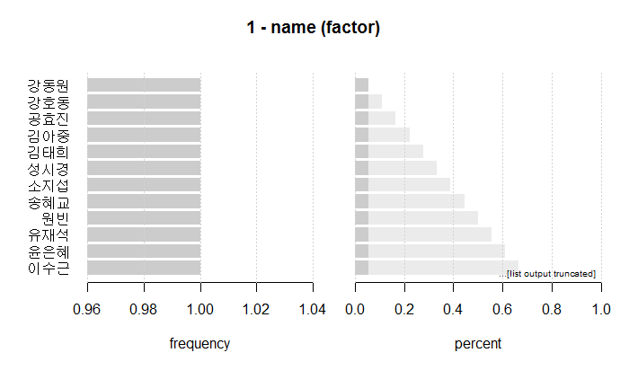

```
---------------------------------------------------------------------------------------------------------------------
3 - ht (integer)

  length       n     NAs  unique      0s    mean  meanCI
      18      17       1      11       0  176.53  172.13
           94.4%    5.6%            0.0%          180.93

     .05     .10     .25  median     .75     .90     .95
  163.80  164.60  170.00  178.00  184.00  186.00  186.40

   range      sd   vcoef     mad     IQR    skew    kurt
   25.00    8.55    0.05   11.86   14.00   -0.23   -1.54
```

| level | freq | perc | cumfreq | cumperc |
| --- | --- | --- | --- | --- |
| 163 | 1 | 5.9% | 1 | 5.9% |
| 164 | 1 | 5.9% | 2 | 11.8% |
| 165 | 1 | 5.9% | 3 | 17.6% |
| 167 | 1 | 5.9% | 4 | 23.5% |
| 170 | 1 | 5.9% | 5 | 29.4% |
| 172 | 2 | 11.8% | 7 | 41.2% |
| 178 | 3 | 17.6% | 10 | 58.8% |
| 182 | 2 | 11.8% | 12 | 70.6% |
| 184 | 1 | 5.9% | 13 | 76.5% |
| 186 | 3 | 17.6% | 16 | 94.1% |

[output cut: 1 more lines]

```
NA
```

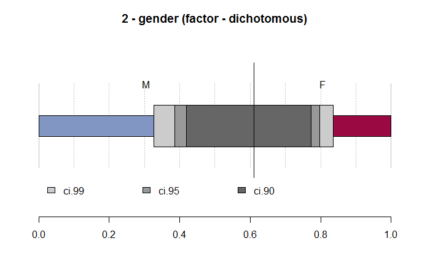

```
---------------------------------------------------------------------------------------------------------------------
4 - wt (integer)

  length       n    NAs  unique     0s   mean  meanCI
      18      18      0      12      0  64.17   55.53
          100.0%   0.0%           0.0%          72.80

     .05     .10    .25  median    .75    .90     .95
   45.00   47.10  49.00   64.00  71.50  80.00   85.25

   range      sd  vcoef     mad    IQR   skew    kurt
   70.00   17.37   0.27   17.79  22.50   1.17    1.48
```

| level | freq | perc | cumfreq | cumperc |
| --- | --- | --- | --- | --- |
| 45 | 2 | 11.1% | 2 | 11.1% |
| 48 | 3 | 16.7% | 5 | 27.8% |
| 52 | 2 | 11.1% | 7 | 38.9% |
| 62 | 1 | 5.6% | 8 | 44.4% |
| 63 | 1 | 5.6% | 9 | 50.0% |
| 65 | 1 | 5.6% | 10 | 55.6% |
| 68 | 2 | 11.1% | 12 | 66.7% |
| 70 | 1 | 5.6% | 13 | 72.2% |
| 72 | 1 | 5.6% | 14 | 77.8% |
| 74 | 1 | 5.6% | 15 | 83.3% |

[output cut: 2 more lines]

```
NA
```

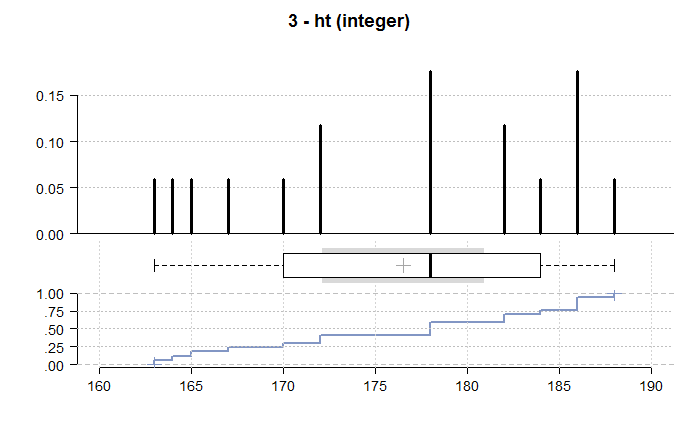

```
---------------------------------------------------------------------------------------------------------------------
5 - bld (factor)

  length      n    NAs unique levels  dupes
      18     18      0      4      4      y
         100.0%   0.0%
```

| level | freq | perc | cumfreq | cumperc |
| --- | --- | --- | --- | --- |
| O | 7 | 38.9% | 7 | 38.9% |
| A | 5 | 27.8% | 12 | 66.7% |
| B | 5 | 27.8% | 17 | 94.4% |
| AB | 1 | 5.6% | 18 | 100.0% |

[output not shown]

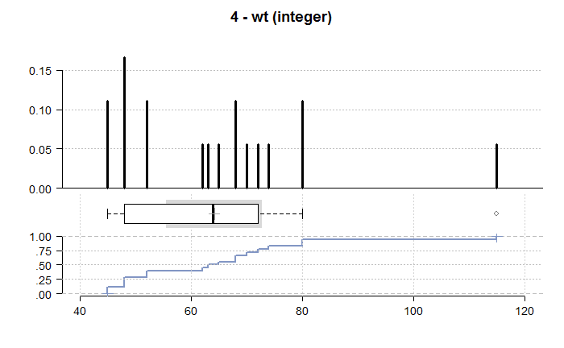

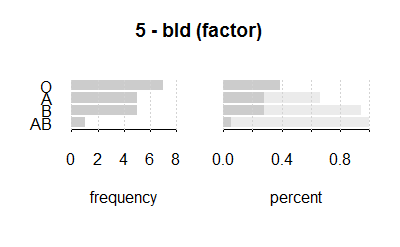

```r
Desc(talent)
```